# EWAS_performance

adowneywall

April 26, 2018

# Empiricial Datasets

#### **Species**:

##### *Baboon*:

Number of individuals: **50**  
Sequencing: **RRBS**  
Methylation Motif: **CpG**  
Data Format: **Read Count Data** (this was converted into proprotion data, beta-values, by dividing the $\frac{number of methylated reads}{number of total reads}$)

**Final filtered dataset Criteria**:

```
##            NAr         bmeanL         bmeanU            bsd     Total_Loci
##           0.00           0.05           0.95           0.01      438787.00
## Remaining_Loci
##      222417.00
```

*NAr*: Threshold of missing values (0=no missing values allowed). *bmeanL*: The lower cut-off for mean locus methylation. *bmeanU*: The upper cut-off for mean locus methylation. *bsd*: Cut-off for standard deviation. *Total_Loci*: Initial number of loci. *Remaining_Loci*: Number after filtering.

##### *Oak (Quercus lobas)*:

Number of individuals: **58**  
Sequencing: **RRBS**  
Methylation Motif: **CpG**,**CHG**,**CHH**  
Data Format: **‘Beta-values’** (proportion data)  
**Final filtered dataset Criteria**: **CpG**

```
##            NAr         bmeanL         bmeanU            bsd     Total_Loci
##           0.00           0.05           0.95           0.01      208376.00
## Remaining_Loci
##        7579.00
```

**CHG**

```
##            NAr         bmeanL         bmeanU            bsd     Total_Loci
##           0.00           0.05           0.95           0.01      177296.00
## Remaining_Loci
##        2450.00
```

**CHH**

```
##            NAr         bmeanL         bmeanU            bsd     Total_Loci
##           0.00           0.05           0.95           0.01      707135.00
## Remaining_Loci
##        3494.00
```

*NAr*: Threshold of missing values (0=no missing values allowed). *bmeanL*: The lower cut-off for mean locus methylation. *bmeanU*: The upper cut-off for mean locus methylation. *bsd*: Cut-off for standard deviation. Total_Loci*: Initial number of loci.* Remaining_Loci*: Number after filtering.

**Distribution of mean methylation across loci for each species**:

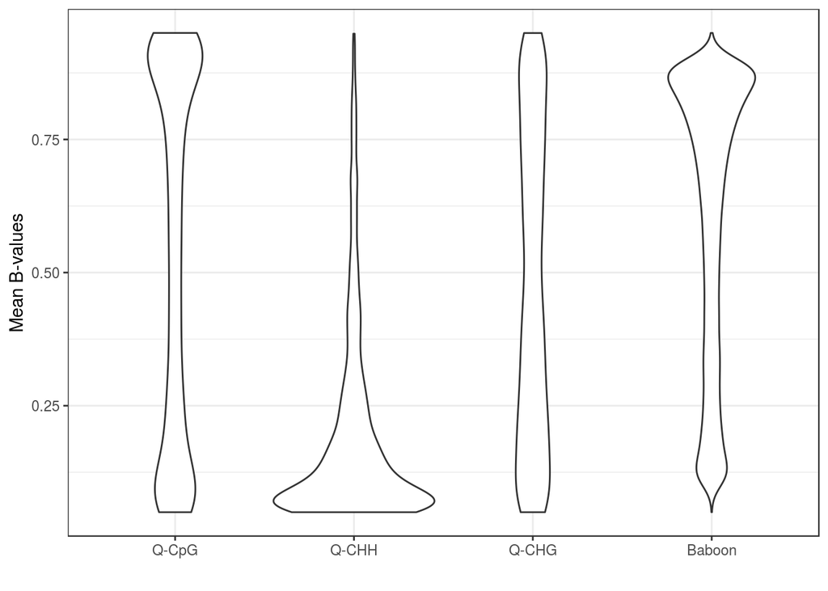

### **Indentifying K (using PCA)**

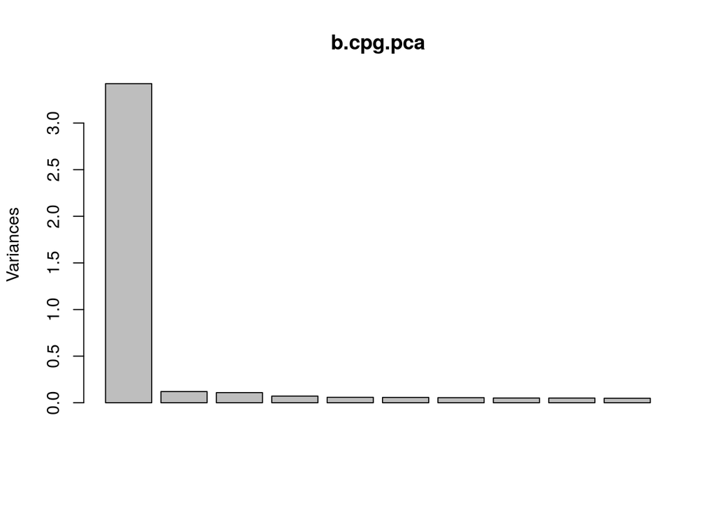

```r
# Baboon Data
b.cpg.pca<-prcomp(b.cpg$B)
screeplot(b.cpg.pca)
```

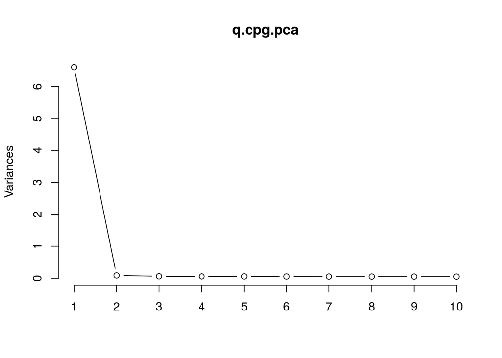

```r
# Oak Data

## CPG
q.cpg.pca<-prcomp(q.cpg$B)
screeplot(q.cpg.pca,type='l')
```

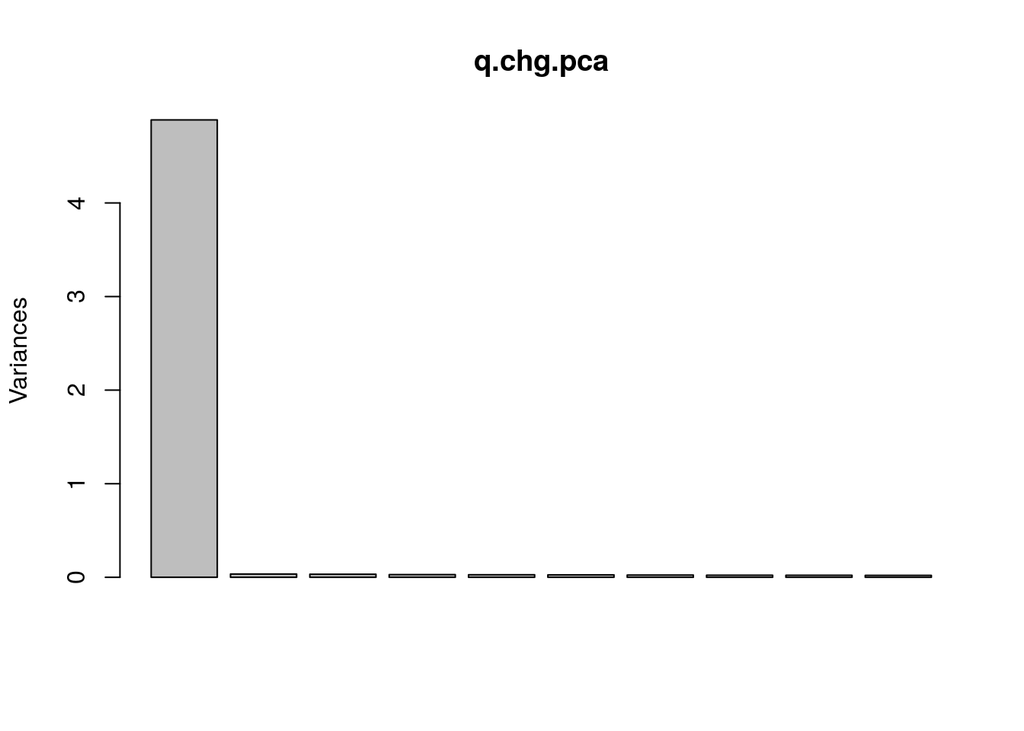

```r
##CHG
q.chg.pca<-prcomp(q.chg$B)
screeplot(q.chg.pca)
```

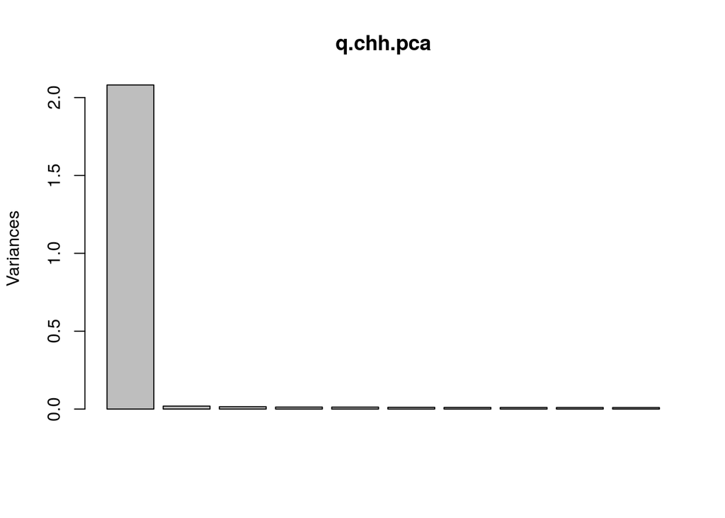

```r
## CHH
q.chh.pca<-prcomp(q.chh$B)
screeplot(q.chh.pca)
```

```r
## All show little variation explained beyond the first PC.
```

## Baboon Association Analysis

#### Using logistic regression (binomial(link=logit))

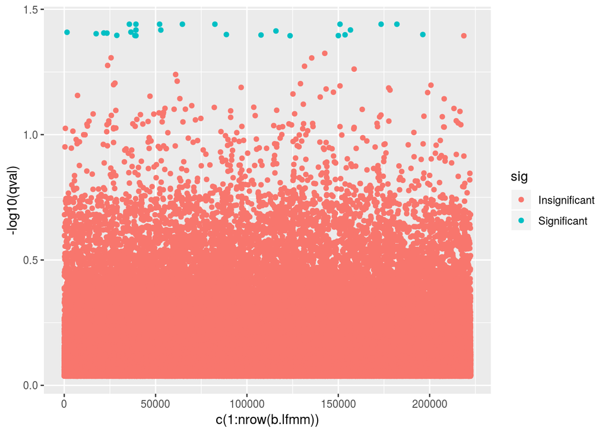

```r
b.b<-b.cpg$B # methylation data
b.meta<-b.cpg$metadata # meta data about locus location on chromosome
b.b.X<-as.matrix(b.X) # predictor

# Regression results using lfmm
## K = 1 (based on scree plots)
## method = Ridge
## pvalues (qvalues) = adjusted using FDRtools (results also saved in list below)

# binomial(link = 'logit') with glm
lfmm.binom<-readRDS("SampleData/Empirical_Data/baboon_example/lfmm_BinomLogit_raw.Rdata")
# Results with binom(link='logit') regression using lfmm latent factors in model
b.lfmm<-cbind.data.frame(b.meta,qval=lfmm.binom$fdrTool$qval)
b.lfmm$sig<-"Insignificant"
# I used a 5% FDR threshold (as determined using the local FDR method from FDRtools)
b.lfmm$sig[lfmm.binom$fdrTool$lfdr <= 0.05] <- "Significant"
ggplot(b.lfmm,aes(x=c(1:nrow(b.lfmm)),y=-log10(qval),colour=sig)) + geom_point()
```

#### Using linear regression

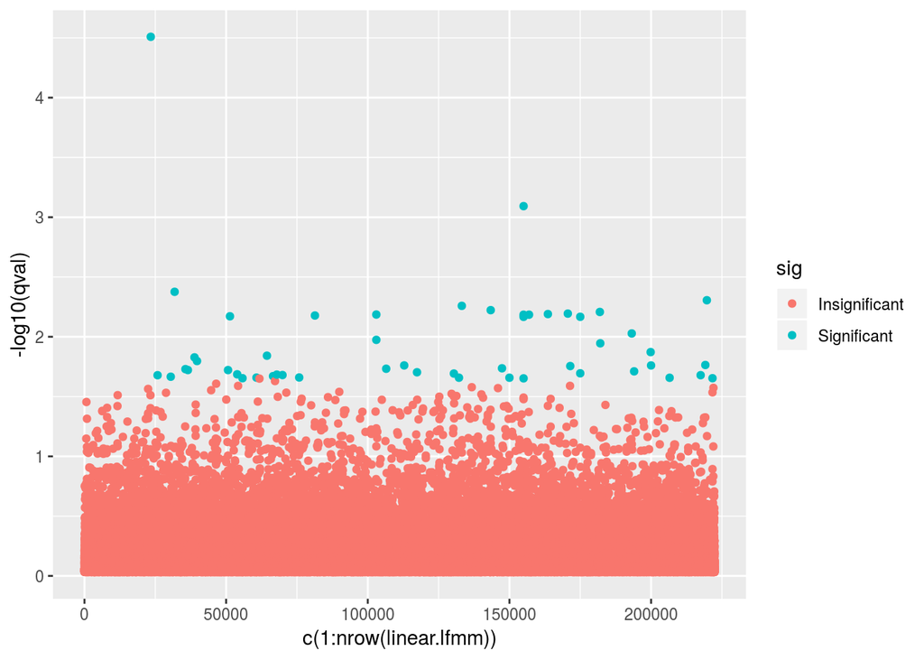

```r
# linear with glm
lfmm.linear<-readRDS("SampleData/Empirical_Data/baboon_example/lfmm_linear_raw.Rdata")

linear.lfmm <- cbind.data.frame(b.meta,qval=lfmm.linear$fdrTool$qval,pcal=lfmm.linear$lfmm_Output$score)
linear.lfmm$sig <-"Insignificant"
# I used a 5% FDR threshold (as determined using the local FDR method from FDRtools)
linear.lfmm$sig[lfmm.linear$fdrTool$lfdr <= 0.05] <-  "Significant"
ggplot(linear.lfmm,aes(x=c(1:nrow(linear.lfmm)),y=-log10(qval),colour=sig)) + geom_point()
```

```r
# Graphs seem pretty 'noisy'
```

#### Overlapping significance

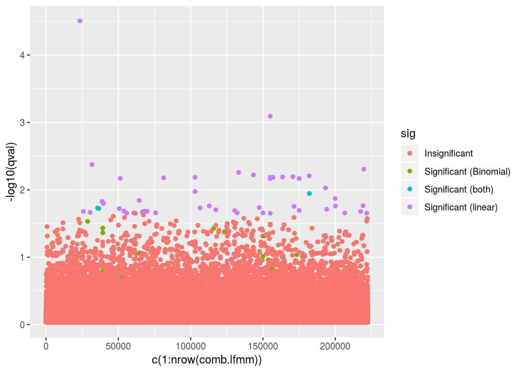

```r
## Using qvalues from the linear regression, the significant values split into points shared between methods and those unique to each.
comb.lfmm <- linear.lfmm
comb.lfmm$sig[comb.lfmm$sig == "Significant"] <- "Significant (linear)"
comb.lfmm$sig[linear.lfmm$sig == "Significant" & b.lfmm$sig == "Significant"] <- "Significant (both)"
comb.lfmm$sig[linear.lfmm$sig == "Insignificant" & b.lfmm$sig == "Significant"] <- "Significant (Binomial)"
ggplot(comb.lfmm,aes(x=c(1:nrow(comb.lfmm)),y=-log10(qval),colour=sig)) + geom_point()
```

## Oak Association Analysis

#### Using logistic regression (binomial(link=logit))

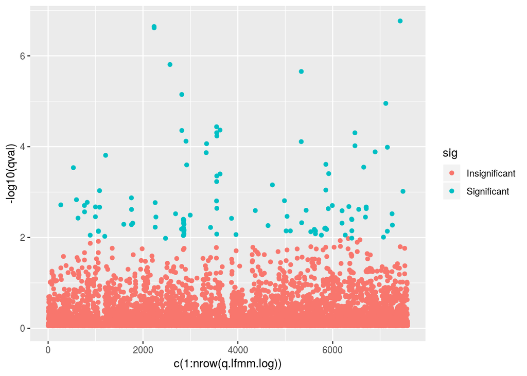

```r
q.cpgM <-q.cpg$B # create Y (methylation data)
q.meta<-q.cpg$metadata
b.b.X<-as.matrix(b.X) #

q.lfmm.logit<-readRDS("SampleData/Empirical_Data/quercus_example/lfmm_BinomLogit_raw.Rdata")

q.lfmm.log<-cbind.data.frame(q.meta,qval=q.lfmm.logit$fdrTool$qval)
q.lfmm.log$sig<-"Insignificant"
q.lfmm.log$sig[q.lfmm.logit$fdrTool$lfdr <= 0.05] <- "Significant"
ggplot(q.lfmm.log,aes(x=c(1:nrow(q.lfmm.log)),
                  y=-log10(qval),
                  colour=sig)) + geom_point()
```

#### Using linear regression

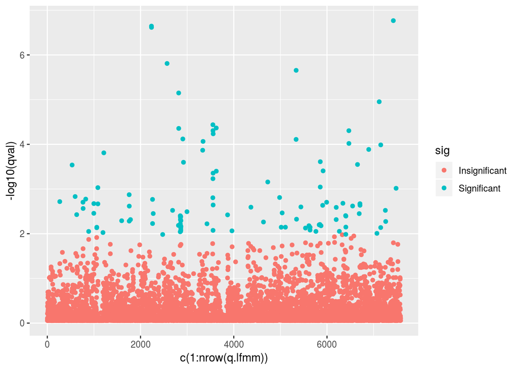

```r
q.lfmm.linear<-readRDS("SampleData/Empirical_Data/quercus_example/lfmm_linear_raw.Rdata")

q.lfmm<-cbind.data.frame(q.meta,qval=q.lfmm.linear$fdrTool$qval)
q.lfmm$sig<-"Insignificant"
q.lfmm$sig[q.lfmm.linear$fdrTool$lfdr <= 0.05] <- "Significant"
ggplot(q.lfmm,aes(x=c(1:nrow(q.lfmm)),
                  y=-log10(qval),
                  colour=sig)) + geom_point()
```

#### Overlapping significance

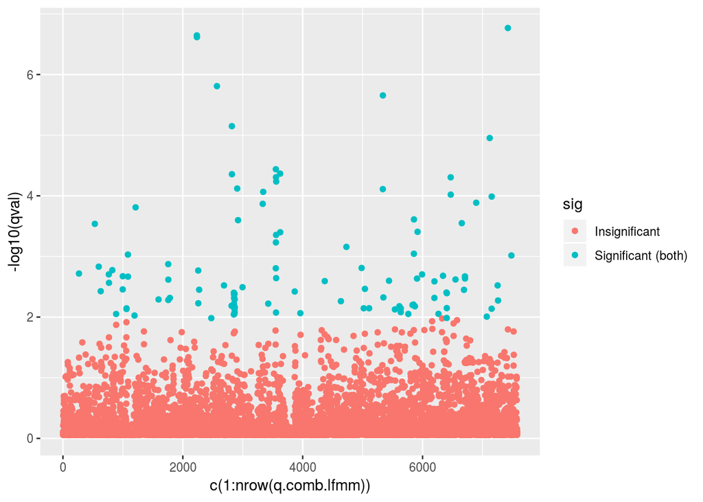

```r
## Using qvalues from the linear regression, the significant values split into points shared between methods and those unique to each.
q.comb.lfmm <- q.lfmm
q.comb.lfmm$sig[q.comb.lfmm$sig == "Significant"] <- "Significant (linear)"
q.comb.lfmm$sig[q.lfmm$sig == "Significant" & q.lfmm.log$sig == "Significant"] <- "Significant (both)"
q.comb.lfmm$sig[q.lfmm$sig == "Insignificant" & q.lfmm.log$sig == "Significant"] <- "Significant (Binomial)"
ggplot(q.comb.lfmm,aes(x=c(1:nrow(q.comb.lfmm)),y=-log10(qval),colour=sig)) + geom_point()
```

# Simulations

## Baboon Simulation

### Simulation 1

##### Parameters:

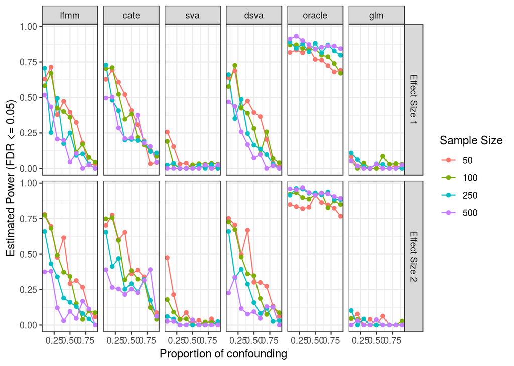

```r
working.df<-readRDS("SampleData/Output_baboonSim/Final01.Rdata")$full.df
ss<-working.df

ss.summary<- ss %>% group_by(n,p,prop.variance,method,mean.B) %>%
  summarise(mean.pFDR = mean(as.numeric(power_fdr),na.rm=T),mean.et0 = mean(as.numeric(et0),na.rm=T),
            mean.eFDR = mean(as.numeric(error_fdr),na.rm=T))
ss.summary<-transform(ss.summary,mean.B = factor(mean.B,levels=1:2,labels=c("Effect Size 1","Effect Size 2")))
## Summary of power that has been fdr corrected
ggplot(ss.summary,aes(x=prop.variance,y=mean.pFDR,colour=as.factor(n))) +
  geom_line() + geom_point() +facet_grid(mean.B~as.factor(method)) +
  theme_bw() + labs(x="Proportion of confounding",y="Estimated Power (FDR <= 0.05)",colour="Sample Size")
```

```r
hitRankDFfix<-readRDS("SampleData/Output_baboonSim/HitRankEst.Rdata")
hitRankSum <- hitRankDFfix %>% group_by(method,sim,hr) %>%
  summarise(mean.q=mean(q),mean.tr=mean(tr),sd.tr=sd(tr))

singleSim<-subset(ss,ss$method == "lfmm" & ss$rep == 1)
singleSim<-singleSim[,c(1,2,7,10)]
names(singleSim)<-c("sim",names(singleSim)[2:4])
hitRankupdate<- inner_join(x=hitRankSum,y=singleSim)
```

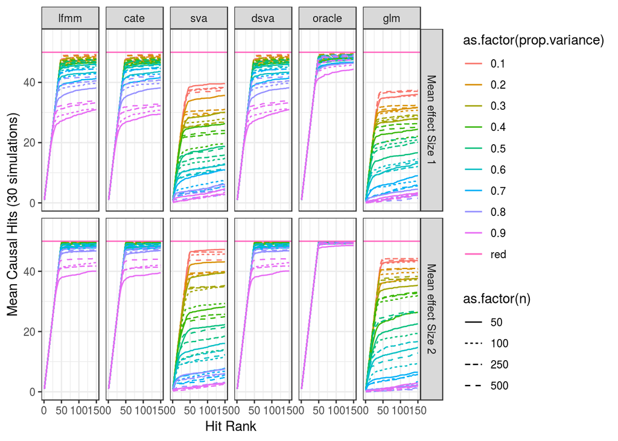

```r
hitRankupdate<-transform(hitRankupdate,method = factor(method,levels=c(2,3,4,5,7,8),labels=c("lfmm","cate","sva","dsva","oracle","glm")))
hitRankupdate<-transform(hitRankupdate,mean.B = factor(mean.B,levels=1:2,labels=c("Mean effect Size 1","Mean effect Size 2")))
ggplot(hitRankupdate,aes(x=hr,y=mean.tr,interaction(as.factor(n),as.factor(prop.variance)),colour=as.factor(prop.variance),linetype=as.factor(n))) +
  geom_line() + facet_grid(as.factor(mean.B)~method) + xlim(0,150) + ylim(0,55) + geom_hline(aes(yintercept=50,colour="red")) +
  theme_bw() + labs(x = "Hit Rank",y = "Mean Causal Hits (30 simulations)")
```

## Qak Simulation

### Simulation 1

##### Parameters:

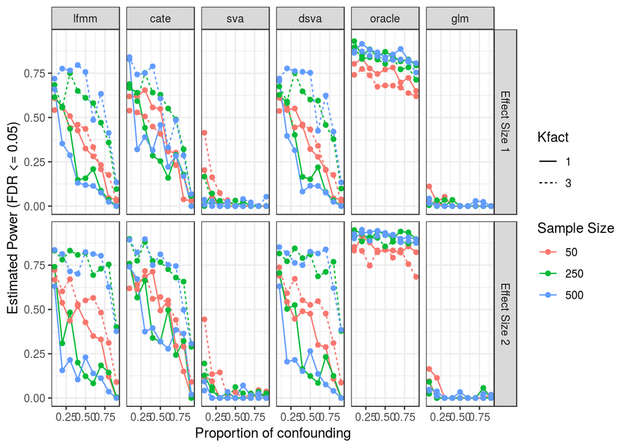

```r
working.q.df<-readRDS("SampleData/Output_quercusSim/FinalSimMethod.Rdata")$full.df

ss<-working.q.df

ss.summary<- ss %>% group_by(n,p,prop.variance,method,mean.B,K) %>%
  summarise(mean.pFDR = mean(as.numeric(power_fdr),na.rm=T),mean.et0 = mean(as.numeric(et0),na.rm=T),
            mean.eFDR = mean(as.numeric(error_fdr),na.rm=T))
#ss.summary$mean.B<-as.factor(ss.summary$mean.B)
ss.summary<-transform(ss.summary,mean.B = factor(mean.B,levels=1:2,labels=c("Effect Size 1","Effect Size 2")))
ss.summary$Kfact<-as.factor(ss.summary$K)

ggplot(ss.summary,aes(x=prop.variance,y=mean.pFDR,group=interaction(as.factor(n),Kfact),colour=as.factor(n),linetype=Kfact)) +
  geom_line() + geom_point() +facet_grid(mean.B~as.factor(method)) +
  theme_bw() + labs(x="Proportion of confounding",y="Estimated Power (FDR <= 0.05)",colour="Sample Size")
```

```r
## Hit Rank vs Predictions

hitRankDFfix<-readRDS("SampleData/Output_quercusSim/hitRankOutput.Rdata")
hitRankSum <- hitRankDFfix %>% group_by(method,sim,hr) %>%
  summarise(mean.q=mean(q),mean.tr=mean(tr),sd.tr=sd(tr))

singleSim<-subset(ss,ss$method == "lfmm" & ss$rep == 1)
singleSim<-singleSim[,c(1,2,4,7,10)]
names(singleSim)<-c("sim",names(singleSim)[2:5])
hitRankupdate<- inner_join(x=hitRankSum,y=singleSim)
```

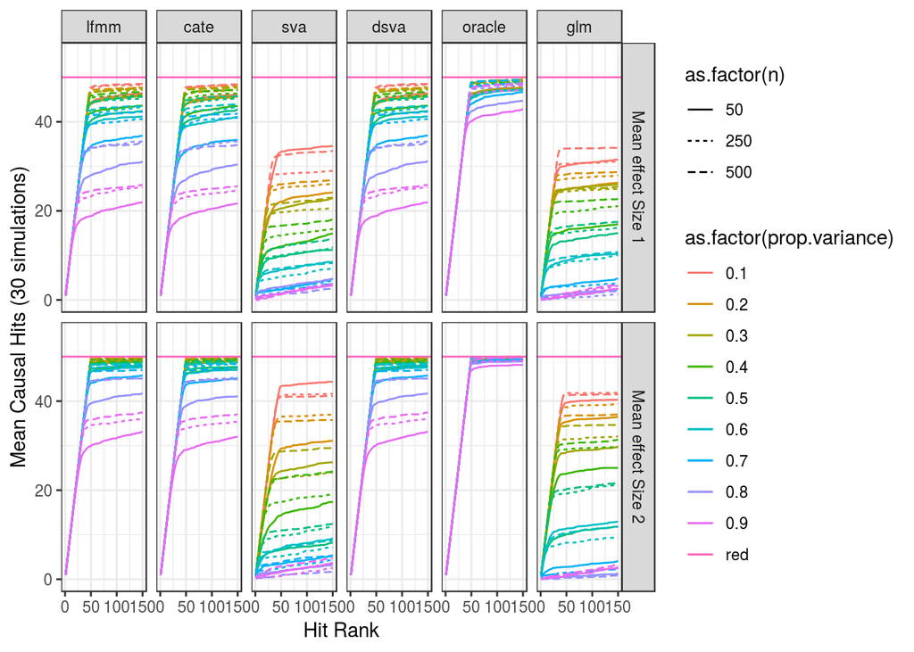

```r
hitRankupdate<-transform(hitRankupdate,method = factor(method,levels=c(2,3,4,5,7,8),labels=c("lfmm","cate","sva","dsva","oracle","glm")))
hitRankupdate<-transform(hitRankupdate,mean.B = factor(mean.B,levels=1:2,labels=c("Mean effect Size 1","Mean effect Size 2")))
hitRankupdate$kfactor<-as.factor(hitRankupdate$K)

hitRanksingleFactor<-subset(hitRankupdate,hitRankupdate$K == "1")
ggplot(hitRanksingleFactor,aes(x=hr,y=mean.tr,interaction(as.factor(n),as.factor(prop.variance)),colour=as.factor(prop.variance),linetype=as.factor(n))) +
  geom_line() + facet_grid(as.factor(mean.B)~method) + xlim(0,150) + ylim(0,55) + geom_hline(aes(yintercept=50,colour="red")) +
  theme_bw() + labs(x = "Hit Rank",y = "Mean Causal Hits (30 simulations)")
```